# Loading and preprocessing the data

## Loading and preprocessing the data

- load the data
- create a separate copy of the data, with NA steps rows removed

```r
setwd("~/datasciencecoursera/05_Reproducible_Research/RepData_PeerAssessment1")
data <- read.csv("activity.csv")
data.rmNA <- data[ !is.na(data$steps), ]
```

## What is mean total number of steps taken per day?

Make a histogram of the total number of steps taken each day

- used the aggregate function to sum the number of steps over each date

Report the mean and median total number of steps taken per day

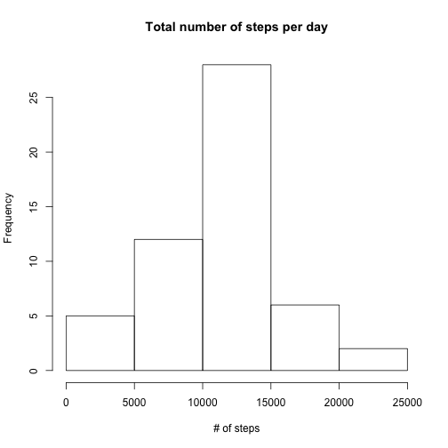

```r
#http://stackoverflow.com/questions/16296657/row-aggregation-according-to-date-in-r-and-sum-corresponding-other-column-values
bydate <- aggregate( data.rmNA$steps, by = list(data.rmNA$date), FUN = "sum")
names(bydate) = c( "date", "steps")
hist(bydate$steps, main = 'Total number of steps per day', xlab = '# of steps')
```

```r
mean(bydate$steps)
```

```
## [1] 10766.19
```

```r
median(bydate$steps)
```

```
## [1] 10765
```

## What is the average daily activity pattern?

Make a time series plot of the 5-minute interval and the average number of steps taken, averaged across all days

- used the aggregate function to calculate the mean number of steps over each interval

Which 5-minute interval, on average across all the days in the dataset, contains the maximum number of steps?

- determine the interval row with the highest # of steps, and display the row

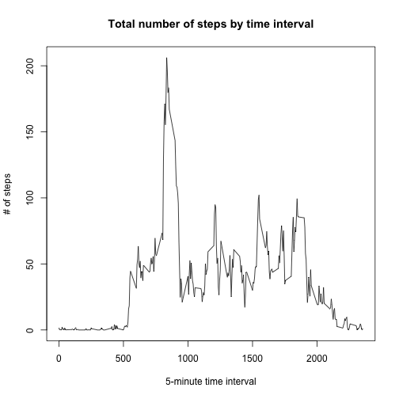

```r
byinterval <- aggregate( data.rmNA$steps, by = list(data.rmNA$interval), FUN = "mean")
names(byinterval) <- c("interval","steps")
plot(byinterval$interval, byinterval$steps, type = "l", main = "Total number of steps by time interval", xlab = "5-minute time interval", ylab = "# of steps")
```

```r
maxintervalindex <- which.max(byinterval$steps)
byinterval[maxintervalindex,]
```

```
##     interval    steps
## 104      835 206.1698
```

## Imputing missing values

Calculate and report the total number of missing values in the dataset (i.e. the total number of rows with NAs)

- prior inspection of the data showed NA's only in the steps column
- also can confirm with complete.cases()

Strategy for filling in all of the missing steps values in the dataset

- for any time interval with NA number of steps, filled in the mean for that 5-minute time interval

Create a new dataset that is equal to the original dataset but with the missing data filled in.

- done by making a copy of the dataset and iterating over every row looking for and replacing NA step values
- relies on the “byinterval” dataframe created previously
- there's almost certainly a better, vectorized way to do this, but I couldn't figure it out

Histogram of the total number of steps taken each day and mean / median reported as before

- based on the method of imputing values, would expect minimal effect on the median / mean on the imputed dataset

```r
sum( is.na(data$steps) )
```

```
## [1] 2304
```

```r
sum(!complete.cases(data))
```

```
## [1] 2304
```

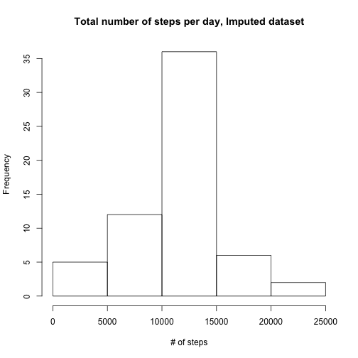

```r
imputed <- data
for (i in 1:nrow(imputed)) { # iterate over every row of the copied dataset
    if ( is.na(imputed[i,]$steps) ) { # if the number of steps for that row is NA...
        interval <- imputed[i,]$interval # figure out what the interval is for that row...
        imputed[i,]$steps <- byinterval[ byinterval$interval == interval, ]$steps # fill in mean # of steps for that interval
    }
}
bydate <- aggregate( imputed$steps, by = list(imputed$date), FUN = "sum")
names(bydate) = c( "date", "steps")
hist(bydate$steps, main = 'Total number of steps per day, Imputed dataset', xlab = '# of steps')
```

```r
mean(bydate$steps)
```

```
## [1] 10766.19
```

```r
median(bydate$steps)
```

```
## [1] 10766.19
```

## Are there differences in activity patterns between weekdays and weekends?

Create a new factor variable in the dataset with two levels – “weekday” and “weekend” indicating whether a given date is a weekday or weekend day.

Plot a comparison of # of steps in each 5-minute interval of the average number of steps taken

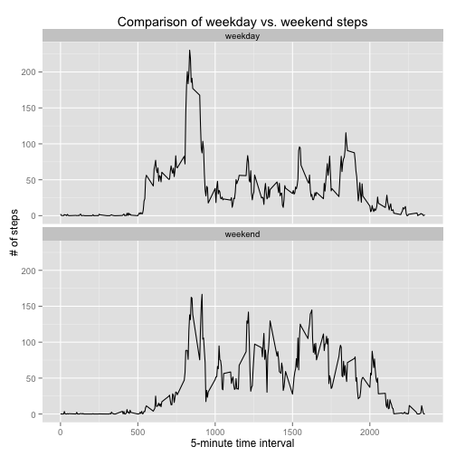

```r
library(car) # from http://stackoverflow.com/questions/14841468/how-to-create-a-new-factor-based-on-a-current-factor
imputed$date <- as.Date(imputed$date)
imputed$dayofweek = as.factor( weekdays(imputed$date) )
imputed$weekfactor <- recode( imputed$dayofweek, "c('Friday','Monday','Thursday','Tuesday','Wednesday') = 'weekday';
                              c('Saturday','Sunday') = 'weekend' ")

byinterval <- aggregate( imputed$steps, by = list(imputed$interval, imputed$weekfactor), FUN = "mean")
names(byinterval) <- c("interval","weekfactor","steps")

library(ggplot2)
g <- ggplot( byinterval, aes(interval, steps, group = weekfactor) )
g + geom_line() + facet_wrap( ~ weekfactor, ncol = 1 ) + labs(title = "Comparison of weekday vs. weekend steps", x = "5-minute time interval", y = "# of steps")
```

## Submission

Requires:

- library(knitr)
- knit2html(“PA1_template.Rmd”)